# Stroop Effect

Karan Thacker

4 September 2017

# Qustion 1

## Identify variables in the experiment

Dependent variable is the time taken to recite the font colors of each word.

Independent variable is the condition applied on the observer , whether it is same font color and word meaning or the word meaning some different color from the font color.

# Question 2

## What is an appropriate set of hypotheses for this task? What kind of statistical test do you expect to perform? Justify your choices.

We want to check whether the difference between the mean of test timing for congruent and incongruent population is statistically different or not.

Out of z test and t test, we would chose to apply a t test as the z test is used for a population with mean and standard devition of population given. Also to scale the difference between two different population , the z test is not applicable.

So this is going to be a t test where first an observer has to go through same color font same word meaning test and then differnet color and word meaning test and note the timing as one observation in each sample.

**null hypothesis** states that there won’t be any significant change in the mean of test timing of congruent and incongruent test takers.

**alternative** states that there will be significant change in the mean of test timming of congruent and incongruent test takers.

(null hypothesis)
$$H_0 : \mu_c - \mu_i = 0$$
(alternative hypothesis)
$$H_a : \mu_c - \mu_i \neq 0$$

the t test wil be **paired sample t test** with critical region lying below p = 0.05.

The reason for paired t test is that the two conditions are being applied on the same sample set making it a dependent sample where each person takes the test of reciting by both methods and his/her observation gets recorded in both sets.

p =0.05 is taken as it is pretty much standard for the unlikely occurence.

Also the test will be **2 tailed** as the alternative hypothesis can go either way with mean population of one condition will come out to be greater than the other.

# Question 3

## Report some descriptive statistics regarding this dataset. Include at least one measure of central tendency and at least one measure of variability.

```
##    Congruent      Incongruent
##  Min.   : 8.63   Min.   :15.69
##  1st Qu.:11.90   1st Qu.:18.72
##  Median :14.36   Median :21.02
##  Mean   :14.05   Mean   :22.02
##  3rd Qu.:16.20   3rd Qu.:24.05
##  Max.   :22.33   Max.   :35.26
```

above is the output of an r code cell which read the data from the csv file and made a dataframe out of it and ran the function summary on it to calculate **mean, median, and the interquartile values of both congruent and incongruent samples.

| Stats | congruent | incongruent |
| --- | --- | --- |
| Mean | 14.05 | 22.02 |
| Median | 14.36 | 21.02 |
| Std dv | 3.56 | 4.80 |
| IQR | 4.30 | 5.33 |

The first two statistical terms are Mean and median for describing the central tendency.

The second two terms are Standard deviation and Interquartile range for showing variability.

All these values have been calculated by R functions summary(), std() and IQR()

# Question 4

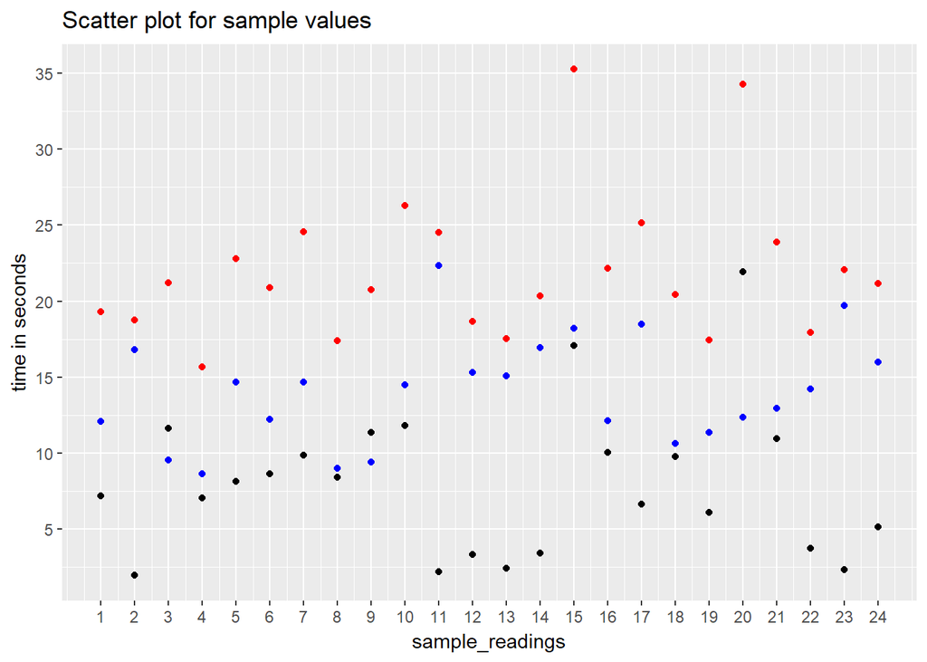

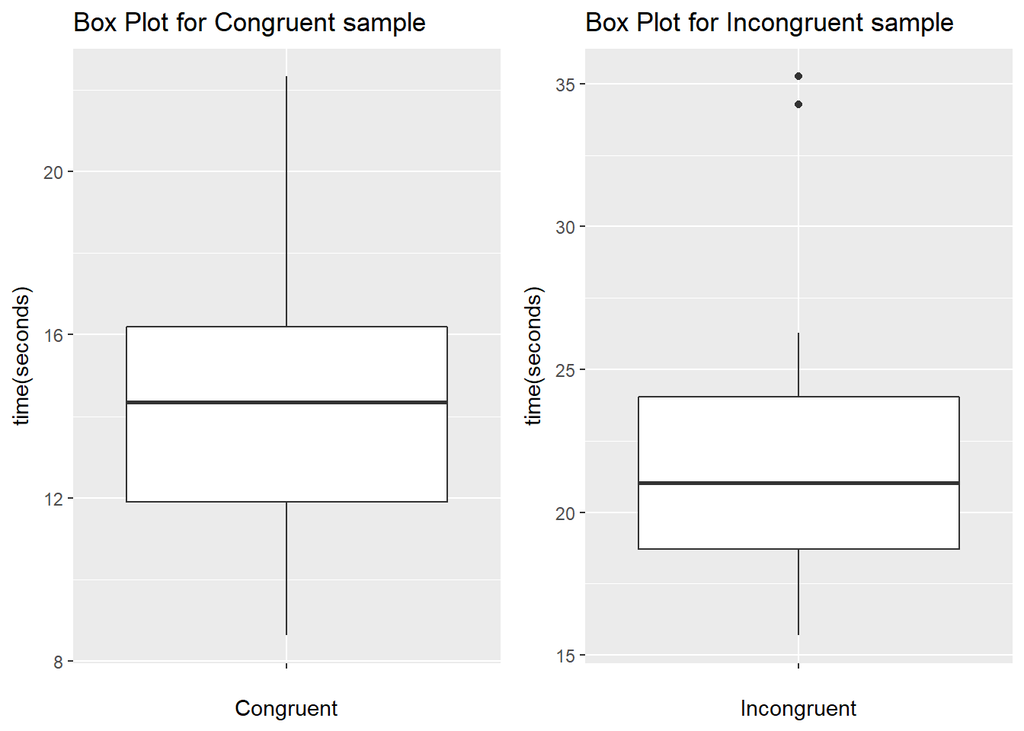

We can compare the range of values, median and all the quartile values between the two samples from their boxplots.

# Question 5

## What is your confidence level and your critical statistic value? Do you reject the null hypothesis or fail to reject it? Come to a conclusion in terms of the experiment task. Did the results match up with your expectations?

Test is two tailed paired t test for p = 0.05 therefore

- t critical (t*) = 2.069 for df = 23
- SD of the differences = 4.86
- SEM = 0.99
- t value = -8.03

So the t value falls way into the left tail critical region making us **reject the null hypothesis**

Therefore we conclude that mean of congruent population is significantly lesse than the the incongruent. Thus establishing the existence of stroop effect.

The 95 per cent confidence interval lies between -10.02(LL) to -5.92(UL). This means that on an average the mean time taken by the congruent recitation will be 10.02 to 5.92 lesser than the incongruent.

The p value for t = -8.03 taken from graphpad website is lesser than **0.0001** Also cohen’s D = -1.64

(* all calculations except t values were rounded to 2 decimal places )

# Question 6

## What do you think is responsible for the effects observed? Can you think of an alternative or similar task that would result in a similar effect? Some research about the problem will be helpful for thinking about these two questions!

The reson behind the slow reciting is that our brain is confused by two simultaneously coming signals , one is trying to interpret the font color and the other is trying to interpret the meaning of word which gets our brain slow to give the desired answer. In simple words the focus of mind is shaken.

Also the other fact which adds on the weight to the dilemma is that our reading processing power is faster. Two recite an incongurent color words is easy for a child who is not yet developed in reading skills. The words have no meaning for the kid.

Other test like these can be randoms names or objects with color but these wont be that prominent. One other thing is emotional stroop effect where the words are negative such as grief, remorse.etc A depressed person will take more time to recite this test than a normal person.